# Practice Problems Answer Key: Statistics for Business Analytics

Author

Riley Svensson

## Introduction

In the field of business analytics, applied statistics play a crucial role in making data-driven decisions. This document serves as a comprehensive practice resource designed to reinforce key statistical concepts through some fun and practical applications. The problems presented are simplified for better understandability while retaining the realism of real-life scenarios, making the learning experience more engaging than typical statistics exercises. Through a series of carefully crafted problems and detailed solutions, this practice test aims to enhance the analytical skills necessary for tackling real-world challenges. Whether you’re a student seeking to deepen your knowledge or a professional looking to refresh your skills, these practice problems provide a valuable opportunity to engage deeply with the material and gain confidence in applying complex yet essential statistical techniques.

```r
library(kableExtra)
```

# Problem 1

##### (Course Concept(s): Expected Value / Variance & Standard Deviation)

Riley is currently a part of 4 different fantasy football leagues, each of which has a grand prize for winning 1st place (winner takes all), and a buy-in to enter the league. A table of the league’s 1st place prize values, buy-ins, and subjective probabilities of success are displayed below. Riley has a track record of placing 1st in League’s 1 and 3, making the probability of winning greater than 1/n, where n is the number of players in the league. For leagues 2 and 4, assume the probability of success is (1/n), and don’t forget the complement rule. Fill in the rest of the table, to include the profit column probabilities of losing, and use this to compute the expected value of Net Profits (P).

(Note: Highlighted sections not would be provided on a test)

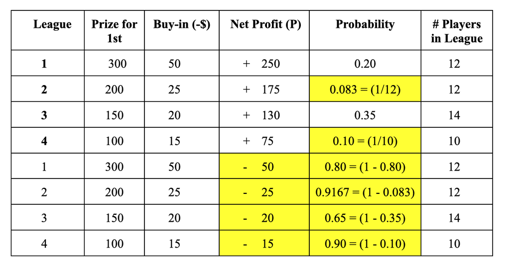

a) Solve for E(P).

**E(P) = P(Win)*(Net Profits) + * P(Lose)*(Net Profits)**

**E(P) = (0.20)(250) + (0.80)(-50) + (0.083)(175) + (0.9167)(-25) + (0.35)(130) + (0.65)(-20) + (0.10)(75) + (0.90)(-15)**

**E(P) = 28.1075 dollars**

b) Explain in context what this number from the previous part is “expected”?

**The value of 28.1075 dollars is the long-run average of net profits that Riley would expect to gain if he repeatedly joined these same 4 leagues with constant probabilities and profit parameters. More simply, if Riley were to join these 4 leagues every year, over and over, he would expect to gain 28.1 dollars on average after many repetitions.**

c) Would it be a good idea for Riley to constantly enter these 4 leagues if he simply wishes to profit in the long-run? What if he expects to make 100$?

**To answer the first part, yes it would be a good idea for Riley to constantly enter these leagues if he wishes to profit from the long-run process, as he can expect 28.1 dollars to be made after many repetitions. However the second’s answer is no, as Riley would still expect 28.1 dollars of profit, even if he were to repeat this process over 100 years. In this case, if more profit is needed, this situation would not be one Riley should repeat.**

d) Compute and interpret Var(P) , SD(P) in context.

Var(P) = $E(P^2)$ - $(E(P))^2$

$E(P^2)$ =$(0.20)(250^2) + (0.80)(-50^2) + (0.083)(175^2)$ $+ (0.9167)(-25^2) + (0.35)(130^2)$

$+ (0.65)(-20^2) + (0.10)(75^2) + (0.90)(-15^2)$

$E(P^2)$ = **18,483.9375**

$(E(P))^2$ = $28.1075^2$ = **790.03**

Var(P) = **18,483.9375 - 790.03**

**Var(P) = 17,693.9075**

SD(P) = $\sqrt{17,693.9075 }$ = **SD(P) = 133. 0184**

**The standard deviation of 133 dollars can be interpreted the following way. In any year of Riley entering these 4 leagues, his actual net profit is expected to be approximately 133 dollars away from the mean of 28.1 dollars, on average.**

# Problem 2

##### (Course Concept(s): Independence / Basic Probability)

Fortnite is a popular video game that follows a battle royale format in which 100 players, are dropped into a map in teams of 4, with the purpose of being the last team standing. Assuming that the placement in a previous game has no effect on the placement of the next game:

a) What’s the probability that my team win’s 3 games in a row?

$P(Win) = 1/25$ **(1 of the 25 teams, 100 players / 4 players = 25 teams)**

**For independent trials:**

**P(Win 3) = P(Win) * P(Win) * P(Win)**

$P(Win 3) = (1/25)^3$ = 0.000064 or 0.0064 %

**The probability that you win three games in a row of Fortnite squads (4 players), is 0.0064%.**

b) What about the probability that you lose 2 in a row, then win 2 in a row?

$P(Win) = 1/25$ **&** $P(Lose) = 24/25$

**P(Lose 2 Win 2) = P(Lose) * P(Lose) * P(Win) * P(Win)**

$P(Lose 2 Win 2) = (24/25)^2 * (1/25)^2$ **= 0.00147 or 0.147 %**

c) Are you more likely to lose 2 in a row then win 2 consecutive, than win 3 straight? By how much?

$P(Lose 2 Win 2)$ **= 0.147 %**

$P(Win 3)$ **= 0.0064 %**

**So, 0.147 / 0.0064 = 22.96**

**In context, you are about 23 times more likely to lose 2 games then win 2 games of Fortnite, than you are to win three games in a row.**

d) Given that you lost the last game, what is the probability that you win the next?

**This is a trick question, as we already were told that the result of a previous game has no effect on the next game, which is describing the concept of independence. In this case where the game’s are all independent of one another, knowing that we lost the last game has NO effect on the probability of winning the next game. It is a separate event, so the probability of winning that game is still, 1/25 or 4 %.**

# Problem 3

##### (Course Concept(s): Basic Probability)

Beer die is a popular college game in SLO that incorporates a 4 x 8 ft wooden board that sits on a table, with 4 cups on each of its corners. A dice is thrown into the air with the purpose to hit the other team’s half of the board, and less likely into one of their 2 cups. **(Assume that the thrower does not miss the table, the die is equally likely to land anywhere on the table, and that a cup has a 3 inch diameter).**

a) Without calculating, what is the probability that you throw a die that lands on the opposing side of the board?

**As the area of the board is 4 x 8 ft or 32 square feet, the probability that your throw lands on the opposing side is simply 50 %, because there are only two places for the die to land, on your half of the table or on your opponents’ half.**

b) Find the probability that the die lands in 1 particular opponent’s cup.

$P(1Cup)$ **= Area of the circle / Total Board area (4 x 8 feet)**

**Area of Circle =** $\pi r^2$ **3 inch diameter = radius of 1.5 in =>** $\pi 1.5^2$ **= 7.0685**

**Area of Board (inches) = (4 ft x 12 in) * (8 ft x 12 in) = 4,608**

$P(1Cup)$ **= 7.0685 sq in / 4,608 sq in**

$P(1Cup)$ **= 0.00153 or .153 %**

**The probability that you throw a die that lands in a particular opponent’s cup, is 0.153 %, assuming you never miss the board.**

c) What about either of the opposing cups?

$P(Opposing Cup)$ **=** $P(1Cup)$ **+** $P(1Cup)$ **or** $P(Any Cup)$ **=** $2*P(1Cup)$

$P(OpposingCup)$ **= 0.00153 * 2 = 0.00306 or .306 %**

**The probability that you throw a die that lands in either of the 2 opponent’s cups, is 0.306 %, assuming you never miss the board.**

# Problem 4

##### (Course Concept(s): Conditional Probability Calculations)

At my house, the outcome of my roommates taking out the trash (to the bins) is dependent on two factors, whether it’s a weekend or weekday, and if they are happy or unhappy. The subjective probability that they are happy is 0.7, create a two way table representing this distribution, and use it to answer the questions below: **(Hint: the probability of being a weekend is 2 days of the 7 days of the week)**

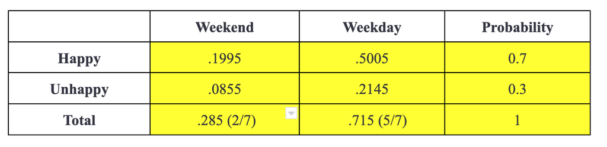

**Process to fill in the table:**

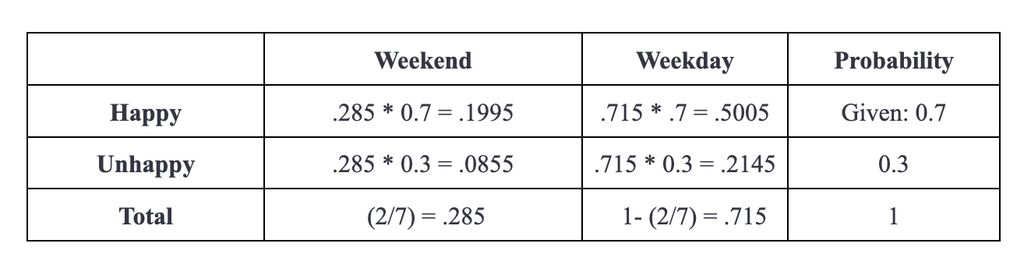

a) What is the probability that they take out the trash, while Happy and on a weekday? What about the opposite, while unhappy on the weekend?

$P(H \cap WD)$ = $P(H)$ * $P(W)$ = .715 * .7 => 0.5005 or 50.05 %

**The probability that my roommates take out the trash while happy and on a weekday, is approximately 50 %.**

$P(UH \cap WE)$ = $P(UH)$ * $P(WE)$ = .285 * .3 = 0.0855 or 8.55 %

**The probability that my roommates take out the trash while unhappy and on a weekend, is 8.55 %.**

b) Given it’s a weekday, what’s the probability of them taking out the trash while happy vs unhappy? Which is more likely and by how much? Interpret in context.

$P(H | WD)$ **=** $P(H\cap WD)$ **/** $P(WD)$ **=> .5005 / .715 = 0.70 or 70 %**

**70 % / 30 % = 2.3 times**

**My roommates are 2.33 times more likely to take out the trash when happy than unhappy, given that it is a weekday.**

c) Given that they are unhappy, what’s the probability they take it out on a weekday vs weekend? Interpret the compared probabilities.

$P(WD | UH)$ **=** $P(WD\cap UH)$ **/** $P(UH)$ **=> .2145 / .30 = 0.715 or 71.5 %**

$P(WE | UH)$ **=** $P(WE\cap UH)$ **/** $P(UH)$ **=> .0855 / .30 = 0.285 or 28.5 %**

d) What is the total probability of them taking it out when happy on a weekend, OR when happy on a weekday.

# Problem 5

##### (Course Concept(s): Discrete Random Variables / Simulation Process / Expected Value )

A soccer player’s number of goals made out of 10 penalty kick attempts takes a Poisson distribution below with a parameter of 4.5. Use the pmf of a Poisson distribution to fill in the table:

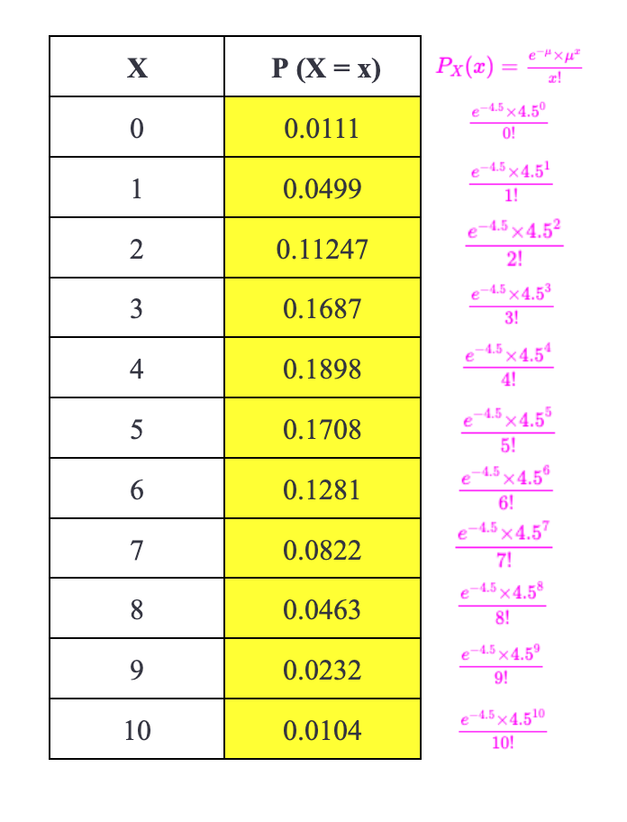

a) Find E(X), interpret, and explain why this makes sense conceptually.

$E(X)$ = 0(0.0111) + 1(0.0499) + 2(0.11247) + 3(0.1687) + 4(0.1898) + 5(0.1708) + 6(0.1281) + (7)(0.0822) + 8(0.0463) + 9(0.0232) + 10(0.0104) = 4.42 or ~ 4.5

**Over many repetitions of this soccer player attempting 10 penalty kicks, we would expect him to score an average of 4.42 goals per set of attempts. This expected value is the long-run average of the 10 attempt trials over time, which intuitively is equal to the parameter that defines this Poisson distribution in 4.5. This makes sense as parameter,** $\mu$ **is the average # of events we expect to see in a given interval, so the** $P(X=x)$ **is the highest around** $\mu$ **, in this case between 4 and 5.**

b) Find $P (X\ge6)$ and interpret.

$P (X\ge6)$ **= Sum of probabilities for each** $x$ **value, provided by the pmf.**

$P (X\ge6)$ **=** $P_X(x = 6) + P_X(x = 7) + P_X(x = 8) + P_X(x = 9) + P_X(x = 10)$

$P (X\ge6)$ **= 0.1281 + 0.0822 + 0.0463 + 0.0232 + 0.0104**

$P(X\ge6)$ **= 0.2902**

**The probability that the player will make at least 6 goals out of 10 attempts is 0.2902. Essentially, a Poisson distribution with a** $\mu$ **of 4.5 goals in the long-run, would expect a player to score 6 goals or more out of 10 attempts, 29 percent of the time.**

c) How many times more times likely to score above 5, than 5 and below? (P(X > 5) / (P(X <= 5)

$P (X>5)$ **=** $P_X(x = 6) + P_X(x = 7) + P_X(x = 8) + P_X(x = 9) + P_X(x = 10)$

$P (X\le5)$ **=** $P_X(x = 0) + P_X(x = 1) + P_X(x = 2) + P_X(x = 3) + P_X(x = 4) + P_X(x = 5)$

$P (X>5)$ **= 0.1281 + 0.0822 + 0.0463 + 0.0232 + 0.0104 = 0.2902**

$P (X\le5)$ **= 0.0111 + 0.0499 + 0.11247 + 0.1687 + 0.1898 + 0.1708 = 0.7027**

$P(X≤5)$ **/** $P (X>5)$ **= 0.7027 / 0.2902 => 2.42**

**According to a Poisson distribution with the parameter of 4.5 representing the # of goals made out of 10 penalty kick attempts, a player would be 2.42 times more likely to score at most 5 goals (**$X\le5$**) than above 5 (**$X>5$**).**

d) Explain two ways that you could simulate this process to approximate the Expected value of goals scored in 10 penalty attempts. (Hint: Create a spinner for #2)

**Simulation 1:**

1. **The first way that you could simulate this distribution to approximate E(X), we could begin by having a player attempt 10 penalty kicks, and record the total count of goals scored.**
2. **The next step would be to repeat this process of 10 shots many, many times, and record the number of shots made each time.**
3. **To approximate the** $E(X)$ **you would sum the counts of the goals (**$x$**) scored on each 10 shot cycle, and divide by the total number of trials (10 shots is 1 trial). This returns an approximation of the long-run average of** $x$**, which in this case, is goals scored over 10 penalty kick attempts.**

**Simulation 2:**

1. **For the second distribution, we could use a Poisson Spinner, that represents the probability of each** $x$ **value (from 0 to 10) based on a** $\mu$ **of 4.5. Using the table we created, the spinner would be display the 10 values of x, with each** $P(X=x)$ **according to the pdf. For example 12.81 % of the spinner would represent X=6 and 18.98 % would be X=4, where** $x$ **is still the number of goals scored.**
2. **To replicate the process of 10 attempts, we would need to spin the spinner 10 times, to simulate one sample, as each spin would be 1 attempt. While spinning, record the total # of goals each time for the 10 total spins.**
3. **The next step would be to repeat steps 2 & 3 many times, to ensure a simulated process.**
4. **Lastly, take the sum of all recorded goals scored for each 10-spin cycle, and divide this by the number of 10-spin cycles, to approximate** $E(X)$**.**

# Problem 6

##### (Course Concept(s): Continuous Random Variables / Probability Density Functions / Uniform & Exponential Distributions)

Imagine you work at a surfboard manufacturing factory as a quality control analyst. In this role you are tasked with ensuring that the surfboard’s sold are reaching the average life-span marketed by our company. Assume the durability of a surfboard (in hours of use) always falls between the lower and higher bound of 400 to 700 hours.

a) What is the probability that a randomly selected surfboard from our factory will last more than 650 hours? (Sketch a picture and use geometry to solve)

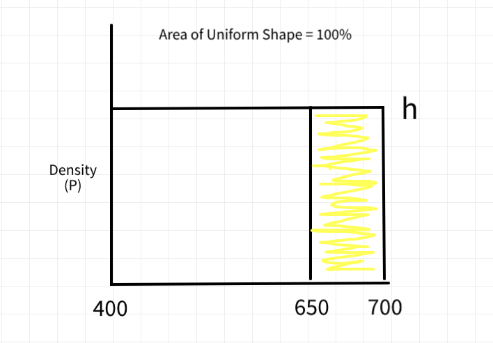

**Area of Yellow = (700 - 50) * h / (700 - 400) * h**

**Area of Yellow = 50h/300h => 0.166667**

**The probability that a randomly selected surfboard from our factory will last more than 650 hours, is 0.16667. Over many, many repetitions of surfboard production, 16.667 % of the boards produced by our company would last between 650 and 700 hours.**

b) If our 1-year warranty is typically measured at around 500 hours of surfboard use, what percentage of the surfboards are expected to fail before reaching this point? (Use pdf to set up and integral & compute.)

**In this case, we are dealing with a uniform distribution from (a,b) in context, (400, 700) hours of surfboard use. The pdf of a Uniform distribution follows the equation:**

$f(x) = \frac{1}{{b - a}}$

**So, after plugging in 400 as our lower bound (a) , 500 as the 1-yr warranty mark, and the (b) and (a) values of 700, 400, the integral is as follows:**

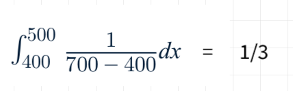

**The probability that a board fails before reaching the 1-yr warranty of 500 hours of use, is 1/3 or 33%. Essentially 33% of all boards produced by the company would not last until the 1-yr warranty, suggesting that the warranty’s date should be adjusted or the company needs to produce longer lasting boards.**

c) A customer claims that their surfboard only lasted 410 hours. What are the chances of this and what does this infer about the customer’s claim? (Hint: compare to $\alpha$ = 0.05)

**The integral for this situation would have a lower bound of 400 again, with 410 now as the upper limit:**

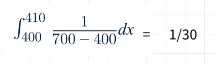

**The probability that a board failed before reaching the 410 hours of use, is 1/30, meaning that only 3.33 % of all boards produced by the company would be expected to fail before 410 hours. This chance of 3.33 % is less than the typical alpha of 5 %, used to indicate random chance could be the cause of our failure, suggesting that the customer might have been lying about the situation or improperly used the product.**

d) What is the probability of a surfboard lasting exactly 650 hrs?

**This is a trick question that requires no computation, as the probability of any given value among a continuous distribution is always 0. This can be explained by the idea that in a continuous distribution, there are an endless number of possible values. In this case between 400 and 700 hours, we have 400.12345 hours as one possible value, while 400.12346 is a completely different value, displaying why we cannot determine the probability of any exact value. Instead, we could phrase the question to find a value close to 650 hours, with a specified margin of error (ex: 60 seconds).**

e) Assume that a surfboard’s durability instead follows exponential distribution with a $\mu = 550$ hours, re-compute parts a and b.

a2)

**The pdf of an Exponential Distribution is given by the equation:**

**To find the probability of a surfboard lasting more than 650 hours, we would need to integrate this function to find the cdf:**

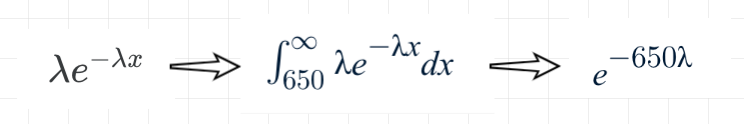

**Remember that** $\lambda$ **is equal to** $\frac{1}{\mu}$ **, so** $\lambda = 1/550$

**Using the cdf, we plug in** $\lambda$ **:**

$e^{-650(1/550)}$ **=** $e^{-1.18}$ **=> 0.3067**

**The probability that a surfboard lastly longer than 650 hours of use is 30.67 %, assuming an exponential distribution. Essentially, only 30.67% of surfboards produced by our company would last more than 650 hours.**

b2)

**To find the probability of a surfboard lasting less than 500 hours, we once again use the cdf:**

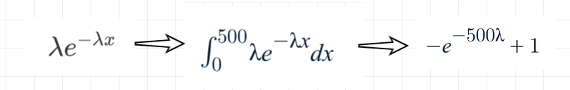

**Using the cdf, plugging in** $\lambda$ **:**

$-e^{-500\lambda}+1$ **=** $1 -e^{-500/550}$ **=> 0.597**

**The probability that a surfboard lastly less than warranty of 500 hours of use is 59.7 %, assuming an exponential distribution. Essentially, 59.7% of surfboards produced by our company would break before the 1-yr warranty.**

# Problem 7

##### (Course Concept(s): Bivariate Normal Distributions / Variance & Standard Deviation / Covariance & Correlation)

Assume that college runners at a track meet are forced to enter both the 100 meter and 200 meter dashes. The times from both of these races, time 1 (T1), and time 2 (T2), follow a Bivariate Normal distribution. Race 1’s average time was 12 seconds with a standard deviation of 2 sec, and Race 2’s average time 22 seconds with a standard deviation of 5 sec, with a correlation ($\rho$) of 0.85.

a) Compute $Var(T1+T2)$ and $SD(T1+T2)$. Interpret in context.

$Var(T1+T2)$ = $Var(T1) + Var(T2) + 2(Cov(T1,T2)$

$Cov(T1,T2)$ = $\rho$ *$SD(T1) * SD(T2)$ **=> 0.85(2)(5) = 8.5**

$Var(T1+T2)$ **=** $2^2$ **+** $5^2$ **+** $2(8.5)$ **=> 46 seconds squared**

$SD(T1 + T2)$ **=** $\sqrt{Var(T1+T2)}$

$SD(T1 + T2)$ **=** $\sqrt{46}$ **=> 6.78 seconds**

**The variance of T1 + T2 indicates how much the combined race times differ from the joint mean of 34 seconds (12 + 22) in squared seconds, while the standard deviation is a simpler measure in useful units, and tells us explicitly that the each runner’s combined race time is expected to be 6.78 seconds from the mean of 34 seconds.**

b) Find the probability that a runner’s total time for both races was above 30 seconds.

$P(T1 + T2) \ge$ **30 sec**

$Z=x−μ/σ$

$\mu$ **= 12 + 22 = 34 ,** $x$ **= 30,** $\sigma$ **= 6.78**

$Z$ **= 30 - 34 / 6.78 = - 0.589 , indicates 30 sec is .589 standard deviations below the total mean of 34 secs.**

**As p-norm returns the cumulative probability to the left of the value, we had to do. 1 - pnorm to get the probability of total running time above 30 sec.**

```r
1- pnorm(q = 30, mean = 34,sd = 6.78)
```

```
[1] 0.7223948
```

**The probability that a runner’s total time for both races is above 30 seconds, is 72.24 %.**

c) Find the probability that a runner’s total time for both races was below 26 seconds.

$P(T1 + T2) <$ **26 sec**

$Z=x−μ/σ$

$\mu$ **= 12 + 22 = 34 ,** $x$ **= 26,** $\sigma$ **= 6.78**

$Z$ **= 26 - 34 / 6.78 = - 1.18 , indicates 30 sec is 1.18 standard deviations below the total mean of 34 secs.**

**In this case, we are interested in the probability of a runner’s total running time below 26 sec, so p-norm returns the value we need.**

```r
pnorm(q = 26, mean = 34,sd = 6.78)
```

```
[1] 0.1190118
```

**The probability that a runner’s total time for both races is below 26 seconds, is 11.9 %. This is a low percentage as 26 seconds is an extremely fast time for the total of the runs.**

d) Find the probability that a runner has a faster time for Race 1 than Race 2. Why does this make conceptual sense?

$P(T1 > T2)$ = $P(T1 - T2) >$ **0**

$\mu$ **= 12 - 22 = -10 ,** $x$ **= 26,** $\sigma$ **=**$SD(T1 - T2)$ **= 3.46**

$Var(T1-T2)$ **=** $Var(T1) + Var(T2) - 2(Cov(T1,T2)$

$Var(T1 - T2)$ **=** $2^2$ **-** $5^2$ **-** $2(0.85(2)(5))$ **= 12**

$SD(T1-T2)$ **=** $\sqrt{Var(T1-T2)}$ **=** $\sqrt{12}$ **=> 3.46**

**Again, we want the probability of the difference in times, above 0, resulting in the use of 1 - p-norm.**

```r
1 - pnorm(q = 0, mean = -10, sd = 3.46)
```

```
[1] 0.001925147
```

# Problem 8

##### (Course Concept(s): Normal Distributions / Simulate Coding)

8) Assume that the number of rap genre songs Riley plays each hour follows a normal distribution with a $\mu$ = 12, and a standard deviation of 3 songs.

a) Use coding to simulate this distribution.

```r
# Ensures that the simulation results are the same every time the code is run
set.seed(123)

# Set number of repetitions
N_reps = 10000

# Simulate random normal distribution with our specified parameters
r = rnorm(n = N_reps, mean = 12, sd = 3)

# Display the first few simulations to ensure reasonable values (~ 12, sd of 3)
head(r) |>
  kable(align = 'c') |>
  kable_styling(bootstrap_options = c('striped', 'bordered'))
```

| x |
| --- |
| 10.31857 |
| 11.30947 |
| 16.67612 |
| 12.21153 |
| 12.38786 |
| 17.14520 |

b) Use the simulation results to approximate the probability that Riley play’s less than 8 rap songs in an hour. Compute using p-norm and compare your results.

```r
# To approximate the probability R < 8 songs, we can simply sum all the repetitions
# in which the # of songs (r) was less than 8, and divide by the total reps (N_reps).

sum(r < 8) / N_reps
```

```
[1] 0.0913
```

**Once again, p-norm can be used to return the combined probability below a given value, so to find the** $P(r<8)$ **we use the code below:**

```r
pnorm(q = 8,mean = 12,sd = 3)
```

```
[1] 0.09121122
```

**The result of the simulation approximate was 9.13 % while the use of p-norm resulted in was 9.12 %, which indicates that we correctly approximated the probability that Riley plays less than 8 rap songs in an hr.**

c) Use the simulation to approximate the probability that Riley play’s more than 20 songs in an hour.

```r
# To approximate the probability R > 20 songs, we can simply sum all the repetitions
# in which the # of songs (r) was more than 8, and divide by the total reps (N_reps).

(sum(r > 20)/N_reps)
```

```
[1] 0.0042
```

**In this case, we are interested in the probability that Riley plays more than 20 rap songs in an hour, so to find the** $P(r>20)$ **we would use (1 - p-norm) below:**

```r
1 - pnorm(q = 20, mean = 12, sd = 3)
```

```
[1] 0.003830381
```

# Problem 9

##### (Course Concept(s): Percentiles / Cumulative Distribution Functions / Quantile Functions / Normal Distributions)

Riley is currently training in an attempt to find the optimal amount of time he spends in an ice bath, by researching the trends of other athletes. He discovers from Banner Health’s ice bath blog that the time athletes typically spend in an ice bath takes a normal distribution with a mean of 12.5 minutes and a standard deviation of 1.25 minutes. Compute $P(x)$ and interpret each value:

a) What is the probability that a randomly selected athlete spends more than 15 minutes in the ice bath?

**In this case, we are interested in the probability that an athlete spends more than 15 minutes in an ice bath, so to find the** $P(time>15)$ **we would use (1 - p-norm) below:**

```r
1 - pnorm(q = 15, mean = 12.5, sd = 1.25)
```

```
[1] 0.02275013
```

**The probability that a randomly selected athlete spends more than 15 minutes in an ice bath is 2.27 %.**

b) It is said that top 5% of athletes who spend the most time in ice baths gain the highest benefits of recovery. What is the minimum time an athlete must spend in the ice bath to be in the top 5%?

**In this problem, we are asked to find a value that corresponds to an ice bath time in the top 5%. The top 5 % is essentially a value higher than 95 % of the others, so we are looking for the 95th percentile. Q-norm can be used below to find a value of x (ice bath time) that corresponds to the 95th percentile:**

```r
qnorm(p = 0.95, mean = 12.5,sd = 1.25)
```

```
[1] 14.55607
```

**An athlete must spend a minimum of 14.55 minutes in an ice bath, to fall within the top 5 % of all athletes’ ice bath times.**

c) If Riley longest time spent in an ice bath is 14 minutes, what percentile does this time correspond to among the distribution of athletes ?

**Here, we are interested in the percentile that corresponds to Riley’s record time of 14 minutes, so we use p-norm to return the % of times that 14 minutes is greater than:**

```r
pnorm(q = 14, mean = 12.5,sd = 1.25)
```

```
[1] 0.8849303
```

**Riley’s time of 14 minutes would be greater than 88.5 % of athlete’s ice bath times.**

d) If he wishes to have a longer time than 75 % of athletes what would his time need to be?

**In this problem, we are asked to find a value that corresponds to an ice bath time, higher than 75 % of athletes, which translates to the top 25%. Q-norm can be used below to find a value of x (ice bath time) that corresponds to the 75th percentile:**

```r
qnorm(p = 0.75, mean = 12.5,sd = 1.25)
```

```
[1] 13.34311
```

**An athlete must spend a minimum of 13.34 minutes in an ice bath, to be in the top 25% of all athletes’ ice bath times.**

# Problem 10

##### (Course Concept(s): Joint & Conditional Distributions)

Riley currently owns 5 different surfboards ranging from sizes small to large, and labeled 1 through 5 respectively. On a weekend, Riley surfs on both days, we’ll call these Day 1 and Day 2, and selects 1 of his 5 boards to go out each day. Each board selection on a given day is random, as it depends on the surf report for that day. Suppose that Riley surf’s on two days every weekend and a potential outcome of the 2 days could be (Day 1 - Board 1, Day 2 - Board 5). Let X be the number of distinct surfboards used over the two days. Let Y be the number of days where Riley surfed a bigger board (4 or 5). Riley prefers all boards the same so there is an equally likely chance of selection for each.

a) Create a table of the different outcomes of board selection and corresponding values of X, Y .

**To create the table below we begin with our two days, and list all the ways Riley could select boards 1-5 on those days. Once we have the 25 different possible outcomes of Riley’s board choice, we can fill in the X column, which can only be 1 or 2 distinct boards used. Lastly, we can count the number of times on each two-day span that Riley used either Board 4 or 5, to fill in the Y column.**

| Day 1 | Day 2 | X (Distinct Boards) | Y (Days with 4 or 5) |
| --- | --- | --- | --- |
| 1 | 1 | 1 | 0 |
| 1 | 2 | 2 | 0 |
| 1 | 3 | 2 | 0 |
| 1 | 4 | 2 | 1 |
| 1 | 5 | 2 | 1 |
| 2 | 1 | 2 | 0 |
| 2 | 2 | 1 | 0 |
| 2 | 3 | 2 | 0 |
| 2 | 4 | 2 | 1 |
| 2 | 5 | 2 | 1 |
| 3 | 1 | 2 | 0 |
| 3 | 2 | 2 | 0 |
| 3 | 3 | 1 | 0 |
| 3 | 4 | 2 | 1 |
| 3 | 5 | 2 | 1 |
| 4 | 1 | 2 | 1 |
| 4 | 2 | 2 | 1 |
| 4 | 3 | 2 | 1 |
| 4 | 4 | 1 | 2 |
| 4 | 5 | 2 | 2 |
| 5 | 1 | 2 | 1 |
| 5 | 2 | 2 | 1 |
| 5 | 3 | 2 | 1 |
| 5 | 4 | 2 | 2 |
| 5 | 5 | 1 | 2 |

b) Create two table’s with the marginal distributions of X and Y .

c) Create a table with the joint distribution of X and Y.

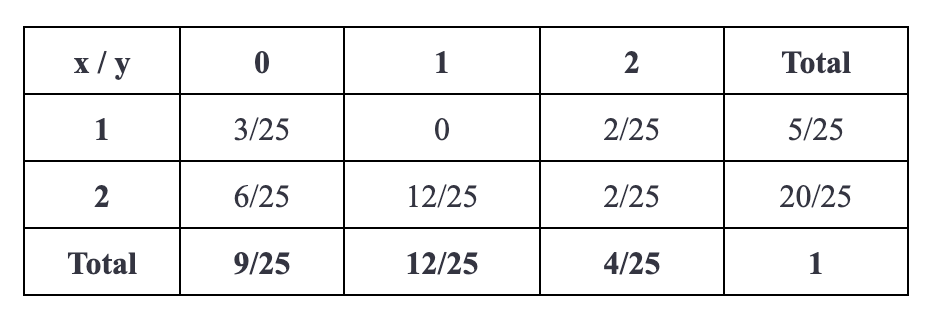

**To create the table above, you count the number of occurrences each (X,Y) pair of has in the table above, and divide by the number of outcomes, 25. For example, a pair of (X = 1, Y = 0) could happen 3 out of the 25 different outcomes, lending it a probability of 3/25.**

d) Create two tables with the conditional joint distributions of $Y|X$ and $X|Y$ , and interpret a value from each table.

$Y|X$ :

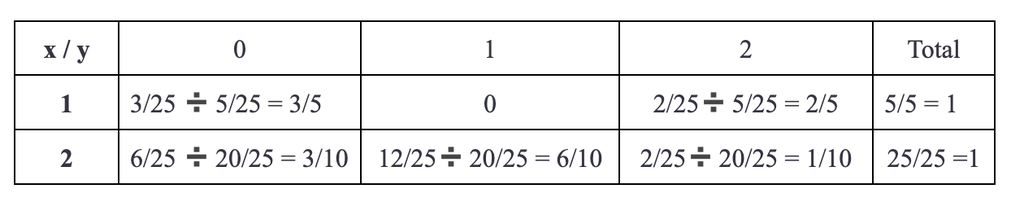

**Given that the number of distinct boards Riley used the same board on the weekend (X=1), the probability that Riley used a bigger board (4 or 5) on each day (Y = 2) is 40 %.**

$X|Y$ :

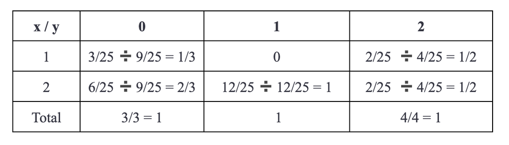

**Given that the Riley used a big board (4 or 5) on 1 day of the weekend (Y = 1), the probability that Riley used two different boards on this weekend (X = 2) is 100 % .** **Essentially if Riley uses a big board once in a weekend, he had to have used 2 different boards.**

e) Are X and Y independent? Prove this with a calculation and explain.

**If** $X$ **and** $Y$ **are independent then** $P(X = 1)$ **should be the same as** $P(X = 1 | Y = 1)$

$P(X=1)$ **= 5/25**

$P(X=1 | Y=1)$ **= 0**

**These probabilities are not equal indicating that X and Y are dependent, as the probability of X is altered by the value of Y. In other words, knowing the value of Y changes the probability each X occurring, and vice versa. In context, the probability of Riley using only 1 board on both days of the weekend, drops from 20% to 0% when we know that he used a big board only once.**

**Another example could be testing if** $P(Y = 2)$ **is equal to** $P(Y = 2 | X = 1)$

$P(Y=2)$ **= 4/25**

$P(Y=2 | X=1)$ **= 2/5**

**The probability of Riley using a big board on both days of the weekend, grows from 16% to 40% when we know that he used 1 distinct board. Once again the probabilities are not equal proving X and Y are not independent.**

### Sources:

6. Symbolab Integral Calculator:

   https://www.symbolab.com/solver/step-by-step/%5Cint_%7B0%7D%5E%7B500%7D%CE%BBe%5E%7B-%CE%BBx%7Ddx?or=input
7. 100 Meter Dash Times:

   https://conditionandnutrition.com/average-time-to-run-100m-data-table-by-age-and-ability/
8. 200 Meter Dash Times:

   https://trackspikes.co.uk/good-200m-time/
9. Athlete Ice Bath Times:

   https://www.bannerhealth.com/healthcareblog/teach-me/ice-baths-are-they-worth-it#:~:text=Cold%2Dwater%20immersion%2C%20also%20known,into%20the%20ice%20bath%20trend